# FSA_note_final

1. 简答题(？道大题)
2. 分析题(？道大题)
   - 课件上的案例不会出现，只会考考点
3. 计算大题

### 第三章 资产分析

#### 固定资产（期中不考！）

- 调整折旧政策 案例：宝钢股份
  - 2003年，钢材价格大涨，钢铁企业利润大大增加
  - 2003年，将年折旧率增加到7%，从而缩减利润90个亿
- 折旧四种方法
  - 年限平均
  - 工作量法
  - 双倍余额递减法
  - 年数总和法
- 关键参数
  - 折旧年限
  - 预计净残值
- 利用资产减值损失进行Big Bath 案例：中海油服
  - 2016年巨亏114.59亿，原因是计提了82.73亿的资产减值损失
  - 2017~2018年，又转回资产减值，从而扭亏为盈
    - 注意：在新准则下，固定资产减值不能转回了
  - 由于计提了大量资产减值损失，还为以后节省了大量折旧
  - 以后出售资产，可以带来更多的账面价值
- 固定资产租赁
  - 经营租赁
  - 融资租赁
    - 会计处理：融资租赁属于*负债*
      - 融资租入固定资产，应当在租赁开始日，按租赁开始日租赁资产的原账面价值与最低租赁付款额的现值两者中较低者作为入账价值。
      - 借记“在建工程”或“固定资产”科目，按最低租赁付款额，贷记“长期应付款-应付融资租赁款” 科目，按其巩额，借记“未确认融资费用”科目。
      - 按期支付融资租赁费时，借记“长期应付款-应付融资租赁款”科目，贷记“银行存款”科目。
      - 租赁期满，如合同规定将设备所有权转归承租企业，应当进行转账，将固定资产仅“融资租入固定资产”明细科目转入有关明细科目。
  - 为什么大部分企业不愿意确认融资租赁，而只将其在表外进行披露呢？
    - $\frac{L}{A} \leq \frac{L+融资租赁}{A+融资租赁}$：容易拉高负债率

##### 在建工程

- 在建工程
  - 准固定资产
    - 期末各项未完工程的实际支出
    - 不提折旧
  - 容易造假：项目虽已完工，但迟迟不转入固定资产，少提折旧，提高利润。
  - 若附注中有一项工程几年都没有完工，应警惕
- 案例：荣华实业
  - 2008至2013年，价值8个亿的在建工程基本停滞，也没有拿出来做抵押
  - 很可能是虚增资产，涉嫌资金挪用

#### 无形资产

- 无形资产的定义
  - 无形资产指没有实物形态的可辨认非货币性资产。
  - 不再区分可辨认无形资产和不可辨认无形资产
  - 把*商誉*排除在外
- 研发支出的规定
  - 企业**研究**阶段的支出**全部费用化**，计入当期损益（管理费用）；
  - **开发**阶段的支出符合条件的才能**资本化**，不符合资本化条件的计入当期损益（管理费用）。
    - 只有同时满足无形资产准则规定的各项条件的，才能确认为无形资产，否则计入当期损益。
    - 如果确实无法区分研究阶段的支出和开发阶段的支出，应将其所发生的研发支出全部费用化，计入当期损益
    - 然而，如何确定研究-开发阶段，主动权其实在公司手中，因此可操纵性较强
- 研发支出资本化案例：大唐电信
  - 研发支出资本化将会夸大企业的资产、净利润、经营性现金流，使企业多缴所得税，损害企业价值。
- 案例：海正药业
  - 主要生产抗生素、抗肿瘤药物
  - 2015年收入同比下降13.17%；归母净利润同比下降95%
  - 2015年之前没有出现“开发支出”(非流动资产)，2015年出现3.34亿开发支出
  - 内部开发支出增加3.09亿，只有5000万转入当期损益
- 借壳上市案例：360公司
  - 2011年在纽交所上市，2015~2016年完成私有化，从纽交所摘牌；2017年借壳江南嘉捷上市，回归A股
  - 为何退出美股？
    - 2015~2020年，大量中概股被对冲基金和做空公司(例如Muddy Water、The Street)做空，还面临着集体诉讼
    - 美股和港股容易导致股价被低估
      - 美股：博纳影业48.55亿
      - A股：光线传媒337.07亿；重新上市的博纳影业100多亿
    - 在美股进行收购会以国家安全理由被调查
  - 借壳流程
    1. 壳公司把资产转给子公司
    2. 把子公司控制权卖给原控制人
    3. 360将自身资产注入壳公司，收购取得控制权
- 研发投入案例：360
  - 2014~2016年，20多亿的研发投入全部计入管理费用，不进行资本化
  - 直到今天，研发投入资本化率始终为0
- 案例：通化金马
  - 1999年~2000年，民营企业三利化工取代国资委成为第一大股东
    - 用2667万买了北京一个公司(营收只有800多万)，另外用3.45亿购买了技术"奇胜胶囊"
  - 2000年，"奇胜胶囊"带来了收益14.85亿
  - 2001年，因为涉嫌国有资产流失，三利化工收购中止
  - 2001年，计提"奇胜胶囊"全部减值准备，理由是“销路不畅”
  - 2002年，又转回减值损失，做了Big Bath
  - 显然，购买"奇胜胶囊"是为了运作无形资产
- 案例：科龙电器
  - 2004年，郎咸平发表《在国退民进盛宴中狂欢的格林柯尔》，针对科龙电器控制人顾雏军
  - 2000年，科龙电器从盈利6.4亿变为亏损6.7亿
  - 2001年，科龙电器EPS降为-1.63元，甚至因为大股东欠款和占用资金被停牌
  - 2002年~2003年，格林柯尔(离岸注册的外资独资)利用多种手法，只用9亿就撬动了100亿的国有资产
    - 安营扎寨：注册大量独资公司，看起来毫无关联
    - 趁虚而入：大量收购经营困难但是品牌较好的国有上市公司
    - 反客为主：股权转让完成之前，就成为公司董事长，让副手成为总裁
    - 投桃报李：和大股东私下交易，低价收购国有股份，以无形资产抵消股东欠款作为交换
    - 洗个大澡：2001年，一次性计提大量减值准备，达成巨亏
    - 相貌迎人：2002年，转回大量费用，达成微利，股价回升
    - 借鸡生蛋：利用科龙的账面现金继续收购其他上市公司

#### 商誉

- 商誉（ goodwill） 的含义？
  - 商誉是指能在未来期间为企业经营带来超额利润的潜在经济价值，或一家企业预期的获利能力超过可辨认资产正常获利能力的资本化价值。
  - 非同一控制下企业合并时，买方对合并成本，大于合并中取得的被购买方可辨认净资产公允价值份额的差额。
  - 简单说，就是收购时支付总对价，高于并购标的净资产公允价值的部分，也可以叫做收购溢价
- 商誉是如何产生的？
  - 商誉产生的根源是收购兼并活动产生的并购溢价
  - 如果没有合并报表，商誉就会转成其他形式的投资
- 收购对价：$$收购对价_t = 公司价值_t *\sum_{i=1}^t 收购比例_i$$
- 商誉：$$ 商誉= 收购对价- 净资产的公允价值×持股比例 $$
  - 若净资产为负，则记为0
- 初始计量：并购成本 & 被并购公司的公允价值(存在操纵空间)
- 后续计量：进行减值测算
  - 测算未来现金流
  - 测试折现率
- 操纵方法
  - 夸大并购价值，虚增规模
  - 无法完成业绩对赌时，索性计提全额损失“Big Bath”
- 商誉 & 无形资产
  - 商誉不是无形资产。无形资产是指企业拥有或者控制的没有实物形态的可辨认非货币性资产。
  - 商誉的存在无法与企业自身分离，不具有可辨认性。而无形资产具有可辨认性。
- 应对商誉风险
  - 计提减值，长痛不如短痛
  - 技术方法：隐藏商誉
  - 将商誉转为长期股权投资
- 商誉减值案例：天神娱乐
  - 2018年曾预测明年大量盈利
  - 2018年，由于传言商誉将转为摊销法，一次性计提全额减值，预计亏损49亿
- 案例：纳斯达
  - 2016年，收购打印机巨头Lexmark，二者营收差距20多倍
  - 2016年，纳斯达合并报表出现188亿的商誉
  - 减少49亿商誉，转入股权投资，避免了大量商誉风险
    - 没有合并报表，也就不再体现为商誉
    - 但是，长期股权投资也会减值
- 减值测试案例：益佰制药
  - 2013年并购女子大药厂，女子大药厂没有完成业绩要求
  - 为什么不计提减值？
    - 在减值测试中，调高了未来现金流，调低了折现率
- 分步并购案例：美年健康
  - 主营业务：体检服务
  - 2003~2015通过收购不断扩张
  - 相比于全科医院，体检医院扩张更加容易，业绩积累期更短
  - “先参后控”方式：
    - 新建体检中心时，先参股$10\%$
    - 体检中心实现盈亏平衡时，再进行控股
    - 业绩稳定时，才$100\%$控股
  - 意义：
    - 减少了初创体检中心亏损带来的业绩影响
    - 参股阶段，投资计入可供出售金融资产，不影响净利润
    - 控股阶段，由于进入合并报表，可以得到子公司估值上升带来的*当期投资收益*
    - 在合并报表中，可以确认*商誉*
    - 全资控股时，购买*少数股权权益*，不用再确认商誉，按照股东间权益交易处理

### 第四章 负债分析

#### 或有负债

- 或有事项：
  - 定义
    - 过去的交易或者事项形成的，其结果须由某些未来事项的发生或不发生才能决定的不确定事项。
  - 主要特征
    - 过去交易或事项形成
    - 具有不确定性
    - 结果由未来事项决定
  - 示例： 未决诉讼/仲裁、债务担保、质量保证、承诺、污染整治、 亏损合同、重组义务、商业承兑汇票背书转让或贴现
- 或有负债可以转回，所以可以以此操控利润

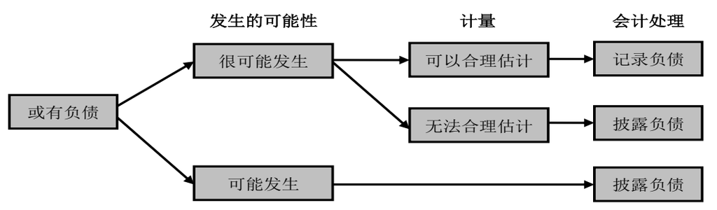

- 案例：紫金矿业
  - 重污染行业都是高或有负债企业，因为如今的环保政策越来越严
  - 1984年，紫金山发现金铜矿；利用污染巨大的“堆浸法”(使用氰化钠溶液)大大减少冶炼成本
  - 2010年，导致$9100m^3$废水流入汀江，引发环保事故
  - 大量潜在的诉讼就是紫金矿业的或有负债
- 案例：鑫茂科技
  - 背景：股权分置改革，公司需要承诺达到业绩指标
  - 2008年，净利润达到2.8亿，此前只有2000多万
  - 原因：转回了2亿多的或有负债(或有负债在2005年计入营业外支出)
    - 或有负债主要来自于日本信越化工的诉讼
  - 法律问题：虽然国内终审赢了，但是信越化工仍然有机会继续诉讼
  - 会计问题：一般要使用*重大会计差错*调整2005年利润，不能调增2008年利润
- 消费积分计划
  - 航空公司为了留住客户，都会用消费积分等方式允许客户兑换奖品
  - 显然，消费积分计划属于或有负债，需要在*财报附注：或有事项*中披露或有负债的置信区间
  - 根据过往数据，需要预测出**预计负债**
  - 实际发生积分兑换时，用**营业成本**冲销预计负债

#### 应付职工薪酬

- 范围
  - 工资
  - 福利费
  - 社会保险
  - 带薪休假
    - 这个怎么计量？
  - 辞退福利
    - 这个好像可以操纵？
- 案例：预银股份
  - 2009年营收增长$31\%$；净利润增长$50\%$
  - 然而，2009年的应付职工薪酬却减少了一半
- 案例：昆明机床
  - 2013~2015年，虚增收入4.83亿
  - 手法：
    - 提前确认收入：产品未发货就计提收入
    - 跨期确认收入：把2014年的收入挪到2015年
    - 虚构收入：客户预提定金，又进行退货，从而虚增收入
  - 伪造货物流、资金流、单据流：
    - 与客户签订虚假合同，虚增收入
    - 设立**帐外库房**，虚假发出货物(根本没组装，发的是零件)
    - 由虚构第三方购回零配件
    - 再通过第三方买回零配件，抵消应收账款
  - 虚减费用：
    - 少计提大量高管薪酬
    - 支付员工内退福利，而后又转回内退福利
- 案例：东方银星
  - 1996年上市前夕，员工多达2000名
  - 2015~2016年，公司仅有11名行政人员，没有生产、销售人员
  - 净利润常年为负，营收弹性极大，一切的努力只是为了保证“上市”正态
  - 虽然经营业绩依托答辩，但是资产负债表特别健康
    - 固定资产比例极低，负债率也很低
    - 虽然从事建材贸易，但是仅依靠建材转销维持
  - 结局
    - 2013~2014年，两大股东豫商集团和银星集团争夺股权，股权比例达到29.999%
      - 要约收购：持有30%上市公司股份时，需要持有足够的现金才能继续收购
    - 最终中庚地产接盘东方银星，2021之前一直保持盈利

#### 短期借款 & 预收账款

- 预收账款
  - 理论上越多越好，代表供应链议价能力比较强
  - 预收账款是一种负债，直到钱货两清，才能确认收入
- 案例：江苏阳光
  - 短期借款达到20.2亿，货币资金高达10.98亿，应付票据高达4.9亿$\to$高现金资产 & 高负债
- 案例：隆平高科
  - 2000年，10大股东中有4名战略投资者，上市2年之后，战略投资者退出；此后公司业绩腰斩
  - 2000年，预收账款仅有1605758；2001年预收账款激增至65079295；2002年又降为39191420
  - 而4名战略投资者却成为了预收账款的9大客户，每家客户支付购货定金700万
    - 显然，公司与战略投资者之间存在共谋
  - 有了大量预收账款，就可以提前确认大量收入，从而拉高股价，战略投资者得以高位套现
- 案例：珠海银邮
  - 2008年，因为内部职工举报而IPO失败
  - 2006~2007年预收账款从5600万减少到960万，而预收账款减少的结果一定是收入增加
  - 现金流量表中的*销售商品收到的现金*可以检验是否真实发生了销售收入
  - 2006~2007年，销售商品收到的现金不增反降，因此可以确定销售收入没有真正增长，增加的收入来自操纵预收账款

#### 应交税金

- 区分：应交税金 & 所得税费用
  - 应交税费主要核算企业按照税法规定计算应交纳的各种税费
    - 包括增值税、消费税、企业所得税、资源税、土地增值税、城市维护建设税、房产税、印花税、个人所得税、土地使用税、车船使用税、教育费附加等。
  - 所得税费用主要核算企业根据所得税准则确认的应从当期利润总额中扣除的所得税费用

#### 税费科目 & 应交税费

- $$支付各项税费＝当期增加的各项税费＋（应交税费期初余额－应交税费期末余额）$$
- $应交税费期末余额＝应交税费期初余额＋当期增加的各项税费－支付各项税费 = 应交税费期初余额＋(税金及附加＋印花税＋所得税费用等)－支付各项税费$
- 案例：天威视讯
  - 2005、2006年应交税费3400多万，2007年减少到472万
  - 相当于上市前1年突击交税
- 案例：飞马国际
  - 2004~2006年，应交税费不断累计，支付税费很少
  - 上市前夕，补交了2000万税费
  - 可见此前企业一直偷税漏税，上市前才补全了税费
- 案例：方园支承
  - 跟之前的案例差不多，2004~2005年偷税漏税

#### 债务重组

- 概念
  - 2021年新准则：*不改变交易对手方*的情况下，双方就清偿债务的时间、金额或方式*重新达成协议*的交易
    - 与旧准则相比，不再强调债务人的*财务困难*和债权人的*让步*
  - 债务重组带来的收益可以计入当期损益
- 债务重组方式(包括以下形式的组合)
  - 用较少的现金偿还债务
    - 账面价值与实际还款直接的差额记为损益
    - 如果债权人已经计提了坏账准备，那么需要先抵消坏账准备
  - 以资产清偿债务
    - 用资产抵债时，按照*公允价值*确认损益
    - 用存货抵债时，增值税销项税额需要被扣除
  - 债转股(债务$\to$资本)
  - 修改其他债务条件
- 案例：世纪星源
  - 1994年，成为中国第一个造假帐停牌后又复牌的公司
  - 1994年，用价值3000万的在建楼宇抵债1.67亿
    - 然而，当时的会计准则还不允许这种操作
  - 1998~1999年，利用1998年的债务重组准则，分别在2年进行“以债抵债”，实现了1亿以上的盈利
  - 2000年，新准则禁止将关联方债务重组收益计入损益
  - 2000年，分别用《房地产买卖合同》和《债务重组协议书》将一笔债务重组业务拆成2笔业务，从而得到了“房地产买卖”的收益
    - 也就是“债务重组资产转让化”
- 案例：ST湖科
  - 2006~2007年连续2年亏损，2008年实现盈利，但是扣非净利润仍然为负
  - 2008年的盈利主要来自债务重组收益390504.59万元

#### 债务解读的问题

- 有些会计上的负债并不表现为法律上的强制义务，有些法律义务也不一定是会计负债
- 应注意是否低估负债，但多提负债≠稳健
- 表外融资优于表内融资
  1. 直接表外负债：
     - 以不转移资产所有权的特殊借款形式直接负债，如经营租赁、代销商品、售后回租
  2. 间接表外负债：
     - 由另一个企业的负债代替本企业的负债，使本企业的表内负债保持在合理限度内
  3. 转移表外负债：
     - 将表内的项目转移到表外进行负债，如应收票据贴现、出售有追索权的应收账款等

### 第4.5章 所有者权益

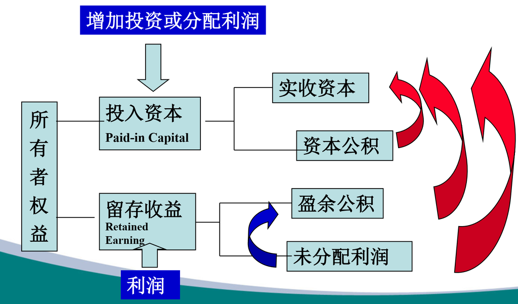

- 定义
  - 所有者权益，是指所有者在企业资产中享有的经济利益，其金额为资产减去负债后的余额。
  - 在资产负债表上，所有者权益应当按照实收资本（或者股本）、资本公积、盈余公积、未分配利润等项目分项列示

#### 实收资本(股本)

- 我国实行的是注册资本制，即实收资本=注册资本。
- 企业可以以现金、实物资产(固定资产、存货)进行投资，也可以以无形资产如与利权、商标权进行投资，但无形资产投资的比例往往在不同的国家受到不同的限制。
- 企业发行的股票有普通股不优先股之区分。
  - 某些国家还允许企业库藏自己的股票，由此形成库藏股 Treasury Stock
- 无形资产出资案例：桂林广维
  - 2013年，索芙特公司宣布增发股票12.8亿收购广维集团，3个月后宣布收购停止
  - 桂林广维主要经营文化旅游表演(“印象刘三姐”)
    - 桂林广维成立时，由广维集团(67%)和广西文华(33%)成立，但是广西文华却一分钱的实收资本没出
    - 广西文华利用演出带来的收益，还上了对广维集团的欠款
    - 2010~2012年，利润稳定增长；2013年，受“八项规定”影响，公款旅游减少，收入断崖式下跌

#### 股票回购

- 股票回购指股份公司以一定的价格购回已发行的流通在外的股票，并予以注销或作为库藏股票（treasury stock）。
- 股票回购减少了流通在外的股票数量，提高公司股票的每股收益，降低了市盈率。
  - 同时，把拟派发现金股利的资金用于股票回购可以节约股东在现金股利上必须支付的税收。
    - 收到现金股利需要交20%的红利税
    - 买卖股票带来的资本利得不用交税
- 股票回购案例：2008年的阿里巴巴
  - 2008年金融危机，为了拉高每股收益，公司都会选择股价较低时回购股票
  - 2008年11月，宣布回购1400万股
  - 截至2009年5月，阿里巴巴股价上升了349%，既展示了公司的信心，也拉高了股价
- 2018年，形成了较为完善的股份回购规定

#### 资本公积

- 资本公积是指所有者的实际投入金额超过其在被投资企业中应享有的注册资本(实收资本)比例的部分。
  - 譬如股票溢价发行时超过股票面额的部分等。
- 资本公积的分类：
  1. 股本溢价
  2. 外币资本折算差额
  3. 接受现金捐赠
  4. 接受非现金捐赠准备
  5. 资产评估增值准备
  6. 股权投资准备
- 股利形式
  1. 现金股利
  2. 股票股利
     - 其本质上并不形成企业的一项负债，而只是所有者权益内部的项目(未分配利润及股本)之间的转化。
     - 此外，20%比例以下的称为股票股利，但若超过20%，则称为股利分割。
       - 前者采用面值进行记录，后者必须采取市场价格。
     - 10送$n$，派现$k$元：
       - 每股得到$\frac{n}{10}$的股票红利与$\frac{k}{10}$的现金红利
     - 拆股/股票分割：
       - 与股票红利不同，拆股是单纯的技术性操作，无需会计处理
  3. 实物/财产股利
     - 可以用于推广新产品

#### 盈余公积

- 盈余公积包括法定盈余公积和任意盈余公积。
  - 法定盈余公积一般按照税后利润的10%提取，当提取的法定盈余公积金额达到注册资本的50%及以上时，企业可以暂停提取盈余公积。
    - 法定盈余公积可以用来转增股本、弥补亏损和支付股利，但转增股本、弥补亏损和支付股利之后的盈余公积不得小于注册资本的25%。
  - 任意盈余公积一般由企业根据实际情况(往往按照10%)从税后利润中提取。

#### 合并报表

合并会计报表又称“合并财务报表”，它是以母公司和子公司组成的企业集团为会计主体，以母公司和子公司单独编制的个别会计报表为基础，由母公司编制的综合反映由母公司与子公司组成的企业集团整体财务状况、经营成果和现金流量情况的会计报表。

- 合并的类型
  - 吸收合并
    - 合并双方只有一方存续，另一方丧失主体地位
  - 新设合并
    - 合并双方均解散，资产和负债转移至新设立公司
  - 控股合并
    - 一家公司收购另一家公司有投票权的股份，两家公司继续单独经营
- 会计处理
  - 吸收合并 & 新设合并

  \begin{aligned} DR&:总资产 ... \\ &CR:总负债 ... \\ & 所有者权益 ... \end{aligned}
  - 控股合并

  \begin{aligned} Dr:& 长期股权投资 ... \\ & CR: 银行存款等资产 ... \\ & 股本 ... \\ & 资本公积 ... \end{aligned}
- 合并方法
  - 同一控制下的企业合并
    - 购买法
    - 按照账面价值合并
  - 非同一控制下的企业合并
    - 权益结合法
    - 按照公允价值合并，需要确认商誉
- 同一控制企业下的合并：泸天化
  - 2005年，九禾农资吸收合并昊源化工
  - 九禾农资和泸天化股份都由泸天化集团控制
  - 吸收合并之后，昊源化工的股东变成九禾农资的股东
1. 谁应当编制合并财务报表？——母公司应当编制和并财务报表。
   - 母公司，是指有一个或一个以上子公司的企业
   - 子公司，是指被母公司控制的企业。
2. 合并财务报表的合并范围应当以控制为基础予以确定
   - 控制，是指一个企业能够决定另一个企业的财务和经营政策，并能据以从另一个企业的经营活动中获取利益的权力。
   - 确定合并范围， 更应当强调实质重于形式原则
     - 母公司要纳入*所有*子公司的报表，不包括合营企业
   - 表决权比例标准
     - 母公司直接或通过子公司间接拥有被投资单位半数以上的表决权， 表明母公司能够控制被投资单位，但是，有证据表明母公司不能控制被投资单位的除外
     - 还需要考虑可转债、认股权证等因素
- 母子公司交易合并利润
  - 母公司与子公司之间的内部交易造成的内部损益需要相互抵消(如果没有对外交易)
  - 即抵消**未实现内部销售损益**
- 分步并购调节利润
  - 在合并财务报表中，对于购买日之前持有的被购买方的股权，应当按照该股权在购买日的公允价值进行重新计量，公允价值不其账面价值的差额计入当期投资收益
  - 分多次并购股权，可以讲并购期间股价上涨带来的利得确认为利润
- 合并报表操纵利润案例：天津磁卡
  - 控制大量子公司，有的子公司纳入合并报表，有的不纳入
  - 有的子公司一段时间纳入，一段时间踢出合并报表(理由：关停并转)
    - 在旧准则中，小规模子公司、关停并转企业、合营企业等可以按企业需求纳入合并报表
- 内部交易操纵利润案例：尔康制药
  - 2014~2016年，营收、利润持续大幅增长
  - 2017年，停牌接受调查后，发布会计差错调整，减少了2亿多净利润
    - 理由：与柬埔寨子公司“沟通不畅”，虚增2亿多利润
  - 通过在母子公司之间嵌入一个共谋的“第三方”经销商，从而绕过了抵消未实现内部销售损益的规定
- 分布并购案例：青岛金王
  - 2017年，青岛金王拿下2.2亿的净利润，但是经营性现金流却是负的，净利润主要来自并购杭州悠可产生的投资收益
  - 这2.2亿的投资收益没有现金流，是分步并购带来的公允价值变动
  - 第一步：并购37%股权，增资后估值上升1.3亿
    - 股权计入“长期股权投资”
  - 第二步：收购剩余63%股权
    - 此时估值上升到10.8亿，原来37%的股权升值到接近4亿，从而得到了2亿多的“收益”
  - 估值上升的理由：
    1. 标的公司规模增长
    2. 标的公司盈利能力增强
    3. 第一次收购是试探，第二次收购是来真的
  - 最终，监管部门认可了金王的解释
- 少数股东权益操纵利润
  - 与少数股东损益纳入母公司并表范围内的子公司，会在母公司和并资产负债表中产生少数股东权益，并且在合并利润表中产生少数股东损益
  - 假设母公司持有子公司$i$的股份
    - 母公司可以得到100%的营收，100%的权益合计，100%的净利润
    - 但只有$i$的*归母净利润*和$i$的*归母权益*
  - 具体手法
    - 为了规避给子公司少数股东的利润，母子公司可以通过*内部交易*、*转移费用*，从而提高归母净利润

#### 会计政策、会计估计变更和差错更正

- 流程图

[figure not shown]

- 会计调整是对以前会计期间所发生的交易或事项的重新表述
  - 包括会计政策、会计估计变更、会计差错更正，以及资产负债表日后对前期会计数据进行的调整或附加披露。
  - 会计调整的经济实质其实是对利益的权衡和协调，牵涉对前期管理者和现任管理者业绩的重新表述，也就是对新老股东各自利益的重新安排。
- 会计估计变更，是指由于资产和负债的当前状况及预期经济利益和义务发生了变化，从而对资产或负债的账面价值或者资产的定期消耗金额进行调整。
  - 例如折旧和摊销的参数和计量方法
1. 会计政策变更 $\to$ 追溯调整法
   - 追溯调整法
     - 对某项交易或事项变更会计政策时，如同该交易或事项初次发生时就开始采用新的会计政策，并以此对相关项目进行调整的方法。
2. 会计估计变更 $\to$ 未来适用法
   - 未来适用法
     - 对某项交易或事项变更会计政策时，新的会计政策适用于变更当期及未来期间发生的交易或事项的方法
     - 只调未来的方法，不用追溯
3. 会计差错更正 $\to$ 追溯重述法
- 案例：TCL
  - 2003年宣布更正2000年的净利润，由2631万盈利变为8600万的亏损
  - 2000年的微利避免了TCL变成ST，所以有可能是会计舞弊

### 第五章 利润表 & 现金流量表

#### 收入分析

- 定义
  - 收入是指一个主体因交付或生产商品，提供劳务或从事构成其持续的（ongoing）主要（major）或中心（central）经营活动的其他业务而形成的（资产）流入、或其他资产价值的增加、或负债清偿（或兼而有之）
- 确认收入的标准(07年旧准则，以后实行20年新准则)
  1. 企业已将商品所有权上的主要风险和报酬转移给购货方
     - 要素
       1. 主要风险和主要报酬两方面都需要同时转移，否则不能确认为收入
       2. “主要风险和报酬”是相对于“次要风险和报酬” 而言的
     - 特殊情况
       1. 委托代销：收取报酬，但是不承担风险，不能确认为收入
       2. 销售退回：顾客拥有退货权，风险没有转移出去，不能确认为收入
       3. 销售回购(售后回购)：先将产品卖出，约定一段时间后购回，因为主要报酬没有转移，不能确认为收入
  2. 企业既没有保留通常与所有权相联系的继续管理权，也没有对已售出的商品实施控制
     - 开发商卖出小区后，仍然继续管理物业，但是这种管理于所有权无关，可以确认为收入
  3. 与交易相关的经济利益很可能流入企业
     - 通常情况下，“很可能”是指发生的概率超过50％的可能性
  4. 相关的收入和成本能够可靠地计量
- 收入操纵九大手法
  1. 寅吃卯粮，透支未来收入
     - 提前确认未来收入，创造“平滑”的收入曲线
     - 方法
       1. 利用补充协议(抽屉协议)，隐瞒风险和报酬尚未转移的亊实
          - 一般公司会选择将退货条款等协议隐藏进补充协议，从而隐瞒风险和报酬尚未转移的亊实
       2. 填塞分销渠道，刺激经销商提前购货
          - 卖方通过向买方提供优厚的商业刺激，诱使买方提前购货，仍而在短期内实现销售收入的大幅增长
       3. 借助开票持有协议，提前确认销售收入
          - 虽然产品还没发货，但是卖方可以提前开发票，从而提前确认收入(即“开票—持有”模式)
  2. 以丰补歉，储备当期收入
     - 通过递延收入或指使被收购企业在收购日之前推迟确认收入等手法，将本应在当期确认的收入推迟至今以后期间确认，并将当期储备的收入在经营陷入困境的年份予以释放
  3. 鱼目混珠，伪造收入性质
     - 上市公司为了迎和华尔街的经营业绩预期，不惜采用鱼目混珠的方法，将非经常性收益包装成主营业务收入。
     - 尽管返种收入操纵手法并不会改变利润总额，但它却歪曲了利润结构，夸大了企业创造经营收入和经营性现金流量的能力
  4. 张冠李戴，歪曲分部收入
     - 在分部报告中，企业可以“拆东墙补西墙”，将利润较多的分部利润调给利润不足的分部
  5. 借鸡生蛋，夸大收入规模
     - 代理代销业务分为买断式和非买断式两种，二者的差别在于风险与报酬是否转移。
     - 对于买断式的代理代销业务，由于风险和报酬已经转移给代理方或受托方，可视同销售，按代理代销总额确认收入。
     - 对于非买断式的代理代销业务，由于风险和报酬依然保留在被代理方或委托方，代理方或受托方应当按代理代销可望收取的净额(如代理佣金)确认收入
  6. 瞒天过海，虚构经营收入
     - 产生收入的业务直接就是虚构的
  7. 里应外合，相互抬高收入
     - 循环交易又称“套换交易”和“背靠背交易” (Back-to Back Transaction)， 是指卖方在向买方出售商品或提供劳务的同时，又按照售价完全一致或十分接近的价格向买方购入资产
  8. 六亲不认，隐瞒关联收入
     - 关联交易的收入是合法的，但是企业为了避免被证券市场过度关注(防止估值下降)，往往会选择隐瞒关联关系与关联收入
     - 典型手段：
       1. 虚构经济业务，人为抬高上市公司业务和效益；
       2. 采用大大高于或低于市场价格的方式，进行购销活动或资产置换；
       3. 以低息或高息发生资金往来，调节财务费用；
       4. 以收取或支付管理费、或分摊共同费用调节利润
     - 财政部政策：关联交易产生的不合理利润计入资本公积而非当期损益
     - 对策：利用复杂的嵌套式股权结构隐瞒关联关系
       - 关联方采购、关联方销售的总量和比例是财报附注中值得关注的部分
  9. 随心所欲，篡改收入分配
     - 企业与客户签订一揽子协议，进行捆绑销售(Bundled Sales)的现象司空见惯。
       - 以捆绑销售的方式进行交易时，每份销售合同通常包含三个要素： 产品销售、资金融通、售后服务，且往往只有一个总价
     - 在捆绑销售中，收入确认最棘手的问题是如何将合同总价分配至各个要素。
       - 其他条件保持相同，资金融通和售后服务要素分配的金额越少，企业能够立即确认的产品销售收入就越多
       - 所以，企业有很强的动机高估产品销售收入，低估融资收入与服务收入
- 案例：美国在线
  - 为了完成与时代华纳的合并，美国在线将2380万的法律纠纷收入包装成广告收入
  - 合并时代华纳后，美国在线强行在时代华纳和高尔夫频道的交易中分了1500万，并且确认为广告收入
- 案例：海宁家纺
  - 主营业务：家用纺织品的商铺出租
  - 2015、2016年，净利润与扣非净利润相差3000万、6000万
  - 净利润大部分来自固定资产处置，也就是卖房
    - 方法：$$ {}\to^{初始购入}投资性房地产\to^{转换(自用)}固定资产\to^{转移出租}固定资产处置 $$
  - 收租方式：
    - 简单模式：$浮动租金$
    - 复杂模式：$固定租金 + 承租费$，海宁家纺使用这种方法
    - 固定租金属于预收款，相当于提前确认收入
    - 此外，海宁家纺的租金也比同行业更高，毛利率可能存在异常
- 案例：天地在线
  - 互联网营销公司，是腾讯的代理商
  - 将“返点”性质的现金流入，确认为了收入，从而被证监会否决
    - 为了把返利确认为收入，将其计入“服务费”，即“具有鼓励性质的收入”
  - 正确的处理：
    - 支付方：将返点确认为销售费用
    - 收取方：将返点确认为冲减的营业成本
- 案例：奎斯特 & 安然宽带
  - 2003年，奎斯特和安然宽带互相置换光纤网络使用权
- 案例：SST重庆实业
  - 1999年重实被控股后，就沦为了德隆系的ATM机
  - 股权结构：中经四通控股，上海万普、上海华岳等公司参股
    - 然而，这些股东实际上都是由德隆国际投资控制的，所以德隆是公司最终控制人
  - 利益输送：
    - 购买股权：
      - 重实大量投资(2.6亿)德隆的未上市子公司山东农超，造成了2.6亿的投资亏损
    - 掏空现金：
      - 通过“资金占用协议”(相当于借款)，借了2.3亿给德农种业，造成2.3亿坏账
    - 违规担保：
      - 给德隆系的公司进行大量担保，形成3.24亿或有负债
- 案例：施乐公司(Xerox)
  - 多数情况下，施乐通过捆绑式租赁协议售卖打印机
  - 2002年，施乐承认通过捆绑销售随意分配基础而虚增收入23.72亿美元

#### 建造合同(旧准则)

- 定义
  - 建造合同， 是指为建造一项或数项在设计、技术、功能、最终用途等方面密切相关的资产而订立的合同
- 分类
  - 固定造价合同，是指按照固定的合同价或固定单价确定工程价款的建造合同。
  - 成本加成合同，是指以合同约定或其他方式议定的成本为基础，加上该成本的一定比例或定额费用确定工程价款的建造合同。
- 收入确认方法
  1. 可以确认完工进度：按照“完工百分比法”确认合同收入
     - $$当期确认的合同收入＝（合同总收入×完工进度）－以前会计年度累计已确认的收入$$
     - 完工进度计算
       - $完工进度 = \frac{累计实际发生的合同成本}{合同预计总成本}$
         - 最常用
         - 通过多计提成本，可以改变各期的净利润，从而实现利润平滑
       - $完工进度 = \frac{已经完成的合同工作量}{合同预计总工作量}$
         - 操纵空间较大
       - $完工进度 = 实际测定的工程进度$
         - 只有以上2种方法都不适用时，才会考虑实地测量
  2. 建造合同的结果不能可靠估计的，分情况进行处理：
     - 合同成本能够收回的，合同收入根据能够收回的实际合同成本予以确认，合同成本在其发生的当期确认为合同费用
     - 合同成本不可能收回的，在发生时立即确认为合同费用，不确认合同收入
- 利用建造合同提前确认收入案例：恒顺众昇
  - 有城投集团控股，主要经营境外工程建设和大型机械设备销售
  - 2014年提前确认2.92亿收入，1.4亿利润
    - 对ASI、MMS销售机械设备，但是以美元披露合同成本和完工进度
    - 2016年合同金额由4.95亿变成9.2亿，完工进度由100%变成17.74%
- 案例：亚太实业
  - 直接改变收入确认方法，删除了“房屋交付使用”的条件
  - 在尚未验收完工的情况下，提前确认了收入
- 案例：嘉寓股份
  - 2010~2013，跨期结转调整利润，实现了“利润平滑”
  - 2010年，按照1000万投入成本正常计量
  - 2012年，投入成本3500万，按照4000万计算，从而多计$500$万利润
  - 2013年，决算当期，补充500万成本，从而调回了500万利润

#### 建造合同(新收入准则)

1. 将现行收入和建造合同两项准则纳入统一的收入确认模型。
2. 现行准则区分销售商品、提供劳务、让渡资产使用权和建造合同，分别采用不同的收入确认模式。
   - 新准则不再区分业务类型，采用统一的收入确认模式。
3. 现行准则收入确认时已“风险报酬转移”为判断依据，而新准则以“控制权转移”为判断依据！
4. 引入了“履约义务”的概念， 明确了如何识别是否存在多个“履约义务”，以及如何将交易价格分摊到多个“履约义务”。
5. 引入“履约进度”计量斱式。
   - 对二在某一段期间履行的履约义务，企业应当
   - 考虑商品的性质，采用产出法或投入法确定恰当的履约进度，幵且按照该履约进度确认收入。
6. 明确了企业应该根据其在交易中的角色是主要责任人还是代理人来确定其收入的金额是总额还是净额。
- 五步法
  - 识别合同
  - 区分履行义务
  - 确定交易定价
  - 分配交易价格
  - 确认收入
- 案例：碧桂园
  - 2017年，利用不同会计准则，提高收入147亿和利润33亿
  - 旧准则：碧桂园预售楼房的收入只能确认为负债，完工之后才能确认为收入
  - 新准则：碧桂园可以按照完工进度分期结算收入
- 案例：电信行业
  - 可以将套餐中“免费”送的手机记为“履约义务”，从而减少成本

##### 净利润

- 特殊现象
  1. 微盈利
     - 从心理学角度看，亏损的上市公司有很强的动机通过做账实现微利
     - 此外，由于证监会要求盈利达到一定水平的企业才能进行股权融资，所以许多公司通过做账来应对要求
  2. 利润过于平稳
- 案例：两面针
  - 2003~2004年，利润非常接近，都是4000多万
  - 2005年上市后，利润下滑到1000万，实际上已经亏损
  - 方法：
    - 虚增销售
    - 少记广告费用

##### 补贴收入

- 补贴收入的原始目的
  - 地方政府根据国家有关产业政策或从地方经济发展的角度出发，对特定行业特定企业给予一定的补贴。
- 但有的财政补贴没有正当理由
  - 完全是地方政府害怕地方的窗口企业失去上市资格，或失去从资本市场上套利以支持地方经济发展的能力，而采取的一种挥霍纳税人金钱的行为
- 政府补助现状
  - 2022年，A股政府补助2473.04亿，5100家公司得到政府补助，占比98%以上
  - 政府补助企业集中在电子、汽车行业
  - 总政府补助占总净利润比例4.38%
- 案例：新疆友好
- 案例：*ST飞彩
  - 为了避免退市，收到财政补贴1.45亿，占当地财政收入87%
- 案例：京东方
  - 2009年，营业利润亏损1.3亿，得到政府补助6亿

#### 现金流量表:结构分析

1. 本期现金从哪来？流往何处去？
2. 三种现金流量的结构分析

\begin{matrix} 经营性现金流 & 融资性现金流 & 投资性现金流 & 分析 \\ + & + & + & 企业经营和投资收益良好，需要了解是否有良好的投资机会\\ - & + & + & 企业靠借债维持经营活动所需资金,财务状况可能恶化\\ + & - & + & 企业债务已进入偿还期,但有足够强的偿债能力\\ + & + & - & 在经营状况良好的前提下,通过筹资进行投资\\ - & - & + & 企业财务状况已经十分危险,偿还债务依靠投资活动现金流量\\ - & + & - & 企业靠借债维持日常生产经营活动,且继续扩大生产规模\\ + & - & - & 企业经营状况良好,在偿还前欠债务的同时继续投资\\ - & - & - & 经营活动现金流出大于流入,投资效率低下,使投入的大量扩张资金难以收回\\ \end{matrix}

- 现金流量表结构分析案例：新疆屯河
  - 流动资产、流动负债在2002年达到巅峰，流动负债远远大于流动资产
    - 形成“短贷长投”的现象，营运资金管理不善
  - 2002年之后，主营业务利润没有同比例增长，净利润虽有1.11亿，但是扣非净利润只有5100万
    - 收入增长前提：将大量资金用于收购，银行借款因此大量上升
    - 2004年，资产负债率达到90%
  - 投资性现金流为负，且远远高于正的经营性现金流
    - 说明公司“放血”过多，但是“造血”功能不足
  - 2001~2003，为了满足资金需求大量借款，融资性现金流较高

##### 经营性现金流

- 计算方法
  1. 直接法
     - $$ 实际经营净现金流入= 销售收入净额 - 销售成本（不含折旧和摊销）- 销售费 - 管理费- 所得税- \Delta WCR $$
     - 其中$\text{Working Capital Requirement(WCR)}=应收款+预付款+存货-预收款-应付款$
  2. 间接法
     - $$ 实际经营净现金流入= 净利润 +[ 折旧+摊销 + 利息] - \Delta WCR$$
       - 重要问题：在经营过程中，你获取多少现金？
     - $获现率=\frac{实际经营NCF}{应得经营NCF}$

#### 营运资本

- 传统观点：
  - 对公司流动资产与流动负债的管理。它要求公司在资金来源与资金占用上应互相匹配，以保证公司短期的偿债能力
  - $WCR=流动资产-流动负债$
- 新观点：
  - 不再过分强调资金来源与资金占用的匹配性，而是要求管理层尽可能多地利用“免费”或“无息”的资金来源，如应付账款等，来满足公司的日常经营需求；同时，在保证流动性的前提下，尽可能多地降低资金在无盈利能力资产上的占用，如应收账款等
  - $WCR=应收款+预付款+存货-预收款-应付款 = 别人占用我的资金 - 我占用别人的资金$
  - 营运资本管理的目标：$\min WCR$
    - 零售业往往能实现负的$WCR$，比如沃尔玛

##### 现金周转期

- 现金周转期
  - $$ 存货周转期 + 应收帐款周转期 = 经营周转期 = 应付帐款支付期 + 现金周转期 $$
1. 存货周转期
   - $$ 存货周转期=\frac{存货}{销售成本}\times 365 $$
2. 应收帐款周转期
   - $$ 应收帐款周转期 = \frac{应收帐款}{销售收入}\times 365 $$
3. 应付帐款支付期
   - $$ 应付帐款支付期 = \frac{应付帐款}{销售成本}\times 365 $$
4. 现金周转期
   - $$ 现金周转期 =存货周转期 + 应收帐款周转期 – 应付帐款支付期 $$
- $WCR$和现金周转期只是同一指标的不同衡量方法
- 营运资本管理案例：苹果
  - 苹果的现金周转期为-68天
  - 苹果的销售部门完全靠供应商的资金运转
  - 通过将预收款投入国债和货币基金，苹果每年可以得到10~15亿的理财收益
- Other People's Money (OPM)案例：ZARA & Shein
  - ZARA的“Fast Fashion”:
    - 从设计到销售，产品周期可以控制在4~5星期内，最快达到15天
  - Shein：
    - 通过自主设计 + 小单快返，将打样到生产缩短至最快7天
    - 类似ZARA，Shein的产品大都由集中在东莞的产业集群生产，订单相应及时
    - 由于Shein从不拖欠货款而且流量很大，因此许多供应商愿意以微利和Shein合作
    - 因为不用承担线下门店成本，Shein的成本可以比H&M和ZARA更低，而且不受疫情带来的负面影响
- OPM案例：格力 & 美的
  - 格力
    - 2016~2020，格力的现金周转期为负，但是绝对值逐渐下降
    - 2021~2022年，格力的现金周转期转正，且持续增长
    - 这说明格力与供应商的谈判优势逐渐减少
  - 美的：
    - 2016~2020，美的的现金周转期也是负的，但不如格力
    - 2021~2022，现金周转期转正，但是也不如格力那么长

##### 基于现金流的财务弹性分析

- 问题
  - 面对市场突然出现的*机遇或逆境*，企业的现金流量和现金储备是否足以应对？
  - 假如企业的*外部融资渠道*突然变窄或融资成本升高，企业是否有能力依靠内部资金维持或扩大经营？
  - 假如企业*经营恶化*，企业是否有能力偿还到期债务？
  - 企业*支付股利*的保障能力如何？
- 现金流量充裕率
  - $$ CF充裕率 = \frac{经营活动净现金流}{固定资产现金流出 + 偿还借款现金流出 + 支付股利现金流出} $$
  - 对资本支出比率
    - $对资本支出比率= \frac{经营活动净现金流}{固定资产现金流出}$
  - 对借款偿还比率
    - $对借款偿还比率= \frac{经营活动净现金流}{偿还借款现金流出}$
  - 对股利支付比率
    - $对股利支付比率= \frac{经营活动净现金流}{支付股利现金流出}$
- 如果$现金流量充裕率>1$,说明存在斟酌性现金流，可以提高企业的流动性和财务弹性

### 第5.5章 报表分析的切入点

- 三大核心问题
  1. 如何比较通用和微软的强弱？
  2. 通用和微软股票市值的反差原因何在？
  3. 如何评价通用和微软的业绩？
- 特征
  - 以规模衡量，通用远远强于微软
  - 自2018年起，微软的经营性现金流超过了通用
  - 自2000年起，微软的股票市值一直是通用的数倍
  - 通用和微软的净资产相差无几
  - 除了特殊的2009年，微软的净利润远远高于通用

##### 三大逻辑切入点

1. 盈利质量
   - 收入质量
     - 成长性
     - 成长性越高，收入和盈利质量越好，说明企业通过主营业务创造现金流量的能力越强
   - 利润质量
     - 波动性
     - 波动性越大，收入和盈利质量越差，说明企业现金流量创造能力和核心竞争力越不稳定
     - 分析波动性还需要将销售收入与宏观经济周期波动结合考察
     - 分析收入和盈利的成长性和波动性最有效的办法是编制**趋势报表**
   - 毛利率
     - 研发 & 营销
     - 毛利率越高，不仅表明企业所提供的产品越高端，也表明企业可用于研究开发以提高产品质量、可用于广告促销以提升企业知名度和产品品牌的空间越大。
     - 而研究开发和广告促销的投入越多，企业就可以培育更多的利润增长点，从而确保企业发展的可持续性。
2. 资产质量
   - 资产结构：长期资产比例
     - 退出风险
       - 存货、固定资产和无形资产占资产总额的比重越高，企业的退出壁垒越高，企业自由选择权就越小
     - 经营风险
       - $\frac{固定成本}{变动成本}$
     - 技术风险
     - 错配风险
       - 注意，以下要素没有在资产负债表上得到反映：
         - 人力资源
         - 品牌资源
         - 研究开发
         - 客户关系
         - 劳资关系
         - 组织结构
         - 内部控制
         - 企业文化
   - 现金含量：现金资产比例
     - 财务弹性
       - 资产的现金含量越高，企业的财务弹性越大。
       - 2001-2005年微软资产总额中的现金含量介于53%-63%之间
         - 虽然后来因为分红、布局投资，微软现金比例有所下降，但是总体保持在50%左右
       - 而通用、福特、克莱斯勒的现金含量很少超过10%，财务弹性极低
     - 潜在损失
       - 资产的现金含量越高，企业发生潜在损失的风险越低
3. 现金流量
   - 经营现金流量
     - 决定“造血功能”
   - 自由现金流量 FCF(Free Cash Flow)
     - 自由裁量资金
     - 广义：$FCF = 经营性现金流 - 资本支出$
       - 用于评估还本付息和股利支付的能力
     - 狭义：$FCF = 经营性现金流 - 资本支出 - 现金股利$
       - 用于评估企业的财务弹性
         - 利用市场机遇和应对市场逆境的能力
       - 用于评估企业依靠内部现金资源谋求发展的能力
- 波士顿矩阵(The Boston Matrix)

```
\begin{matrix}
      &市场成长性：高 & 市场成长性：低 \\
    市场占有率：高 & \text{Stars} & \text{Cash Cows} \\
    市场占有率：低 & \text{Problem  Children} & \text{Dogs}
\end{matrix}
```

1. Stars (现金明星)
   - PLC处于高速成长阶段，市场占有率很高且仍呈上升趋势
   - 销售收入和现金流量有很高的增长潜力
   - 获利丰厚，但现金流量不很充裕
2. Cash Cows(现金奶牛)
   - 市场占有率很高
   - PLC处于成熟阶段
   - 产品维持成本较低
   - 现金性收入很高
   - 经营性现金流量十分充裕
3. Dogs(现金瘦狗)
   - PLC处于衰退阶段
   - 市场占有率很低或不断下降
   - 经营性现金流量入不敷出
   - 产品需要大量维持支出
4. Problem Child(问题小孩)
   - PLC处于高速成长阶段，但市场占有率很低
   - 产品维持需要大量资金支出
   - 经营性现金流量可能出现负数
   - 未来潜力充满不确定性
- 总结
  - 三大汽车公司与M的案例分析表明，从财务角度看，盈利质量、资产质量和现金流量是系统、有效的分析财务报表的三大逻辑切入点
  - 盈利质量、资产质量和现金流量是相互关联的
    - 盈利质量的高低受到资产质量和现金流量的直接影响
      - 如果资产质量低下，计价基础没有夯实，报告再多的盈利都是毫无意义的。
      - 如果企业每年都报告盈利，但经营性现金流量却入不敷出，这种性质的盈利，要么质量低下，要么含有虚假成分
    - 资产质量也受到现金流量的影响。
      - 根据资产的定义，不能带来现金流量的资产项目，充其量只能称为“虚拟资产”

### 第六章 财务比率分析

##### PCVRG

1. 盈利能力 Profitability
   - 损益表s
     1. 毛利
     2. 营业利润
        - $营业利润 = EBIT - 财务费用$
     3. EBIT 息税前利润
        - (Earnings Before Interest and Taxes)
     4. EBITDA 息税前利润+折旧+摊销
        - (Earnings Before Interest, Taxes, Depreciation and Amortization)
     5. EBT 税前利润
     6. EAT 税后利润
        - $EAT = 净利润 - 优先股股利 - 财务费用$
   - 盈利能力指标
     - 销售利润率
       1. $$ 营业利润率= \frac{营业利润}{销售收入} $$
       2. $ EBIT利润率= \frac{EBIT}{销售收入} $
       3. $ EBITDA利润率 = \frac{EBITDA}{销售收入} $
       4. $$ 销售净利润率 = \frac{税后利润}{销售收入} $$
     - 资产利润率
       1. $ {ROA}_1= \frac{营业利润}{总资产} $
       2. $ {ROA}_2= \frac{EBIT}{总资产} $
       3. $ {ROA}_{税后}= \frac{{EBIT}\times (1-T)}{总资产} $
       4. $ {ROA}_3 = \frac{税后利润}{总资产} $
       5. $ 总资产净利润率 = \frac{净利润}{总资产} $
     - 资本利润率
       1. $$ ROE = \frac{税后利润}{权益资本} $$
       2. $ 投入资本净利润率= \frac{税后利润}{投入资本} $
       3. $ 税前投入资本报酬率 = ROIC = \frac{EBIT}{投入资本} $
       4. $$ 税后投入资本报酬率 = 税后ROIC = \frac{EBIT\times (1-T)}{投入资本} $$
1. 创造现金能力
   1. 获现率
      - 在经营中获得现金的能力
      - $$ 获现率 = \frac{实际经营净现金}{应得净现金} $$
        - 对于少部分企业，可以实现$获现率>1$
        - 其中$应得净现金 = 净利润+折旧 + 摊销+利息$
      - $$ 调整获现率 = \frac{实际经营净现金 + (应收票据 - 应付票据)}{应得净现金 + 资产减值}$$
        - 应收票据和应付票据具有银行或商业承兑的特征，所以应该纳入考量净现金
   2. 净利润现金含量
      - $$ 净利润现金含量 = \frac{税后经营净现金}{净利润} $$
        - 表明每元净利润所含的经营性净现金
   - 其他指标
     1. 现金销售比
        - $ 现金销售比= \frac{销售所得现金收入}{销售收入}$
     2. 销售获现率
        - $销售获现率 = \frac{税后经营净现金}{销售收入}$
     3. 总资产获现率
        - $ 总资产获现率= \frac{税后经营净现金}{总资产}$
     4. 投入资本获现率
        - $ 投入资本获现率= \frac{税后经营净现金}{投入资本}$
     5. 权益资本获现率
        - $ 权益资本获现率 = \frac{税后经营净现金}{权益资本}$
1. 创造市值能力
   - EVA 经济增加值，经济利润
     - 在支付利息和股东合适报酬之后的“超额收益”或“剩余收益”

     \begin{aligned} EVA &= 调整净利润 - 股东方面的成本 \\ &= 调整净利润 - (权益资本\times 股东预期收益率)\\ &= {EBIT}\times(1-T) - 投入资本\times 加权平均资本成本(WACC)\\ \end{aligned}
   - MVA 市场增加值
     - 企业（资产）的市场价值与投入资本之间的差额

     \begin{aligned} MVA &= \frac{EVA}{WACC -g} \\ &= 企业的市场价值 - 企业的投入资本 \\ &= 企业负债资本的市场价值 + 企业股权资本的市场价值 - 企业的投入资本 \end{aligned}
   - 其他指标
     1. 投入资本创值率
        - $$投入资本创值率 = \frac{EVA}{投入资本}$$
     2. 市值面值比
        - $市值面值比 = \frac{股票价格}{股票面值}$
     3. 权益资本创值率
        - $权益资本创值率 = \frac{EVA}{权益资本}$
1. 风险控制能力
   1. 经营风险
      - $$ \begin{aligned} 经营风险 &= \frac{\Delta EBIT\%}{\Delta 销售量\%} \\ &= \frac{销售收入 - 总变动成本}{销售收入 - 总变动成本 - 总固定成本}\\ &= \frac{单价 - 单位产品可变成本}{单价 - 单位产品可变成本 - \frac{总固定成本}{销售量}} \end{aligned} $$
   2. 财务风险
      - $$ \begin{aligned} 财务风险 &= \frac{\Delta 净利润\%}{\Delta EBIT\%} \\ &= \frac{销售收入 - 总变动成本 - 总固定成本}{销售收入 - 总变动成本 - 总固定成本 - 利息} \\ &= \frac{单价 - 单位产品变动成本- \frac{总固定成本}{销售量}}{单价 - 单位产品变动成本 - \frac{总固定成本}{销售量}- \frac{利息}{销售量}} \end{aligned} $$
   3. 总风险
      - $$ \begin{aligned} 总风险 &= \frac{\Delta 净利润\%}{\Delta 销售量\%} \\ &= 经营风险\times 财务风险 \\ &= \frac{销售收入 - 总变动成本}{销售收入 - 总变动成本 - 总固定成本 - 利息} \\ &= \frac{单价 - 单位产品可变成本}{单价 - 单位产品变动成本 - \frac{总固定成本}{销售量}- \frac{利息}{销售量}} \end{aligned} $$
1. 成长性
   1. 销售收入增长率
      - $$ 销售收入增长率 = \Delta 销售收入 \% = \frac{销售收入_t - 销售收入_{t-1}}{销售收入_{t-1}} \times 100\% $$
   2. 自我可持续增长率
      - $$ g = \Delta 股东权益 \% = ROE \times 留存收益比例 $$
   3. 净利润增长率
      - $$ 净利润增长率 = \Delta 净利润 \% =\frac{净利润_t - 净利润_{t-1}}{净利润_{t-1}} \times 100\% $$
   4. 经营净现金增长率
      - $$ 经营净现金增长率 = \Delta 经营净现金\% = \frac{经营净现金_t - 经营净现金{t-1}}{经营净现金_{t-1}} \times 100\% $$
   5. 营业利润增长率
      - $ 营业利润增长率 = \Delta 营业利润 \% = \frac{营业利润_t - 营业利润_{t-1}}{营业利润_{t-1}} \times 100\% $
   6. 总资产增长率
      - $ 总资产增长率 = \Delta 总资产\% = \frac{总资产_t - 总资产_{t-1}}{总资产_{t-1}} \times 100\% $
   7. 净资产增长率
      - $ 净资产增长率 = \Delta 净资产\% = \frac{净资产_t - 净资产_{t-1}}{净资产_{t-1}} \times 100\% $
1. 资本市场表现
   1. 每股利润 EPS
      - $$ EPS = \frac{净利润}{普通股}$$
   2. 市盈率
      - $$ 市盈率 = \frac{每股价格}{EPS}$$
   3. 股票收益率
      - $$ 股票收益率 = \frac{S_{t} - S_{t-1}}{S_{t-1}} + \frac{D_t}{S_{t-1}}$$
      - 其中$D_t$表示分红，$S_t$表示股价
   4. 每股净资产
      - $ 每股净资产 = \frac{净资产}{普通股}$
   5. 每股现金流
      - $ 每股现金流 = \frac{税后经营性净现金}{普通股}$
   6. 每股分红 DPS
      - $ DPS = \frac{现金股利}{普通股} = \frac{净利润\times(1-留存收益比例)}{普通股}$
   7. 股价-资产比
      - $ 股价资产比 = \frac{每股价格}{每股净资产}$
   8. 股价-现金比
      - $ 股价现金比 = \frac{每股价格}{每股经营性净现金}$
1. 流动性
   1. 流动比率
      - $$ 流动比率 = \frac{流动资产}{流动负债} $$
   2. 现金比率
      - $$ 现金比率 = \frac{货币资金}{流动负债 or 短期有息负债} $$
   3. 速动比率
      - $ 速动比率 = \frac{流动资产 - 存货}{流动负债} $
   4. 营运资本需求量(WCR)比率
      - $营运资本需求量比率 = \frac{WCR}{总资产} = \frac{流动资产 - 流动负债}{总资产}$
1. 偿债能力
   1. 总资产负债率
      - $$ 总资产负债率 = \frac{总负债}{总资产} $$
   2. 权益乘数
      - $$ 权益乘数 = \frac{总资产}{权益资本} $$
   3. 利息保障倍数(现金)
      - $$ 利息保障倍数 = 税前经营性净现金 -（折旧 + 摊销） \text{ or } \frac{现金资产 - 短期有息债 - 应付款}{应付利息} $$
   4. 净负债率
      - $ 净负债率 = \frac{总负债-预收款}{总资产} $
   5. 有息负债率
      - $ 有息负债率 = \frac{有息负债}{总资产} \text{ or } \frac{有息负债}{投入资本} $
   6. 权益资产比
      - $ 权益资产比 = \frac{权益资本}{总资产} $
   7. 权益负债比
      - $ 权益负债比 = \frac{权益资本}{长期负债} $
   8. 利息保障倍数(EBIT)
      - $ 利息保障倍数 = \frac{EBIT}{应付利息} $
   9. 本息保障倍数(现金)
      - $ 本息保障倍数 = \frac{税前经营性净现金}{应付利息 + 应还本金} \text{ or } \frac{现金资产}{应付利息 + 应还本金} $
   10. 本息保障倍数(EBITDA)
       - $ 本息保障倍数 = \frac{EBITDA}{应付利息 + 应还本金} $
1. 资产运营能力
   1. 总资产周转率
      - $$ 总资产周转率 = \frac{销售收入}{总资产}$$
   2. 固定资产周转次数
      - $固定资产周转次数 = \frac{销售收入}{固定资产}$
   3. 存货周转天数
      - $存货周转天数 = \frac{存货}{销售收入}\times 365$
   4. 应收账款周转天数
      - $应收账款周转天数 = \frac{应收账款}{销售收入}\times 365$
1. 资本成本
   1. 加权平均资本成本 WACC
      - $$ WACC = \frac{有成本负债}{投入资本}\times (1-T)K_D + \frac{权益资本}{投入资本}\times K_S= \frac{负债价值}{总价值}\times (1-T)K_D + \frac{权益价值}{总价值}\times K_S$$
   2. 权益资本成本 $K_S$
      - $K_S = \frac{D_{t}}{P_{t-1}} + g = R_f + \beta(R_m - R_f) = 无风险利率 + 风险溢筹$
      - 可以用CAPM模型估计
   3. 债务资本成本 $K_D$
      - $K_D = (1-T)\times 贷款利率$
      - 用债券定价公式中的YTM估计$K_D$:$P_0 = \sum_{t=1}^{n}\frac{I_t}{(1+K_D)^t} + \frac{FV}{(1+K_D)^n}$
   4. 优先股资本成本 $K_P$
      - $K_P = \frac{优先股股利}{优先股股价}$

##### 财务分析方法：传统 & 现代

- 传统财务比率
  1. 盈利能力
  2. 资产使用效率
  3. 资产流动性
  4. 负债管理能力
  5. 现金创造能力
  6. 财富创造能力
  7. 资本市场表现
- 三维分析
  - 趋势分析(纵向)
  - 同业比较(横向)
  - 结构分析
- 三维分析案例：联想 vs 戴尔
  - 同业比较：
    - 现金销售比：戴尔从2008~2012保持高位；联想在2008年出现负数，2012年接近0
  - 结构分析：
    - 2005左右，流动资产从70%以上减少到50%左右
      - 原因：联想在2005年用大量现金收购IBM的PC部门
    - 2005年，并购引起了商誉(此时还属于无形资产)大量增长
    - 为了进行并购，其他应付款占比上升17%左右，说明联想用流动负债为收购融资
      - 这种行为构成了“短贷长投”，具有很大财务风险
- 案例：福耀玻璃
  - 2018年卖出子公司带来了30%的净利润增长，2019年又因为计提长期股权投资减值损失而导致利润减少
    - 除此以外，利润基本稳定增长
  - 营业收入、经营性现金流、净利润同步增长
  - 获现率、净利润现金含量都大于1，说明福耀玻璃的利润是有“真金白银”的
- 案例：康师傅 & 达利园
  - 总收益
    - 康师傅的总收益增长较稳定，主要由方便面和饮料构成
    - 达利园的总收益较不稳定，产品比较多元化
  - 资产负债表
    - 2020年前，达利园无有息负债，此后负债开始增加、净利润减少
    - 康师傅的规模约是达利园3倍，但是盈利能力、偿债能力不如达利园
      - 达利园的负债率明显小于康师傅
    - 达利园成长性可能不如康师傅
    - 达利园的流动资产比例在70%左右，高于康师傅的50%左右
  - 利润表
    - 达利园的毛利率高于康师傅，但差别不大
    - 费用率整体变动不大，康师傅的销售费用率高于达利园3%左右
    - 虽然销售收入较少，但是达利园的所得税税负高于康师傅
  - 现金流量表
    - 现金流量表的结构分析是将一年内的现金流量转化为几年内的现金流量占比
- 财务比率分析案例：苹果
  - 负债率
    - 2012年，乔布斯去世后，有息负债率从0开始快速增长
    - 苹果负债率的上升与股利政策变化有关，从不分红变为大规模分红
    - 虽然苹果的现金足以支付股利，但是库克还是选择举债分红
      - 借债可以产生税盾效应，从而减少税收成本
      - 苹果的信用很好，融资成本很低，加上抵扣的税收，实际利率只有1%
      - 最主要的原因：苹果的现金存放在各地分部，而离岸现金调回总部需要缴纳35%的高额税收
    - 由于此前苹果的投资者看重公司的成长性，苹果的分红政策使投资者减少了对苹果成长性的信心
  - 2021、2022年ROE超过100%，但是获现率却小于1
- 案例：同仁堂 & 云南白药
  - 概况
    - 2010年，云南白药规模和收入远高于同仁堂，但是经营性现金流却不如同仁堂
      - 白药的有息负债非常低，所有者权益和同仁堂差距不大，说明白药的财务杠杆利用较好
    - 2013年以前，同仁堂股价一直不如白药，2011年还经历了股价大跌
    - 2013年，白药股价大跌，股价低点低于同仁堂
  - 盈利能力
    - 同仁堂销售利润率高于白药；
    - 但是白药的ROA、ROE高于同仁堂
  - 资产使用效率
    - 云南白药各项周转次数都大于同仁堂
    - 说明白药的资产使用效率较高
    - 但是白药的资产周转次数呈下降趋势，这是由流动资产周转次数下降导致的
  - 资产流动性
    - 同仁堂的流动比率、速动比率等明显高于白药
  - 负债比率
    - 同仁堂的有息负债率和总资产负债率明显高于白药
    - 2012年，长期负债的增加导致同仁堂的负债率大幅上升
    - 云南白药有息负债率极低，说明白药善于利用“无息负债”
  - 偿债能力
    - 两家公司偿债能力都很强
  - 创现能力
    - 同仁堂的创现能力显著强于白药
    - 两家公司的创现能力都在减弱
    - 同仁堂的获现率稳定在50%以上
    - 而白药的获现率不超过50%，2011年获现率为负
  - 创值能力
    - 同仁堂的EPS明显低于白药
    - 总结：
      - 云南白药是“创值不创现”，存在大量白条利润
      - 同仁堂是“创现不创值”，需要提高资本盈利能力

#### 基于PCVRG的商业模式评价

##### 盈利模式：分解ROE

- 三因素杜邦分析
  - $$ ROE = 净利润率 \times 总资产周转率 \times 财务杠杆 = \frac{净利润}{销售收入} \times \frac{销售收入}{总资产} \times \frac{总资产}{净资产} $$
- 案例：中兴通讯
  - 2007年推行股权分置改革，要求高管保证ROE在10%以上
  - 2000~2006年，ROE一路下降，2007年以后ROE重新增长至10%以上
  - 股权激励完成后，中兴通讯实际上由高管控股，成为实质上的私营企业
  - 然而，和2006年相比，净利润率和总资产周转率变化不大，负债率却增加了10%，从而使ROE增加到10.94%
  - 2011年，股权激励解锁，高管得以套现，ROE下降到8%，负债率却依然增加至80%以上
  - 2012年，中兴首次出现亏损
- 五因素分解：
  - $$ ROE = \frac{EBIT}{销售收入} \times \frac{销售收入}{投入资本} \times \frac{税前利润}{EBIT} \times \frac{投入资本}{权益} \times \frac{净利润}{税前利润} $$
  - 经营性竞争优势
    - $\frac{EBIT}{销售收入} \times \frac{销售收入}{投入资本} = \frac{EBIT}{投入资本} = ROIC$
  - 财务性竞争优势
    - $\frac{税前利润}{EBIT} \times \frac{投入资本}{权益}$
  - 税费优势
    - $\frac{净利润}{税前利润}$
- 案例：“美苏大战” 苏宁 & 国美
  - 苏宁：内涵式扩张
    - EBIT利润率较高
    - 有息负债率极低
  - 国美：外延式扩张
    - 06年以后，国美的ROE落后于苏宁
      - 原因：
      - 苏宁的EBIT利润率、资本周转率显著高于国美
      - 国美的财务杠杆始终较高
      - 国美的$\frac{投入资本}{权益}$高于苏宁，体现了较好的资本运营能力
      - 08年以前，国美的实际税负高于苏宁

#### 创现模式：分解获现率

- 获现率
  - 在经营中获得现金的能力
    - $$ 获现率 = \frac{实际经营净现金}{应得净现金} $$
      - 理论上，获取现金能力较好的企业应该实现$获现率>1$，但现实中只有少部分企业可以实现
      - 其中$应得净现金 = 净利润+折旧 + 摊销+利息$
      - 企业在经营过程中必须赚取经营净现金，以保障企业债权人的利息是真金白银的利息；股东的利润是真金白银的利润；股东和债权人当年回收的本金即折旧和摊销，也是真金白银的现金回收
    - $$ 调整获现率 = \frac{实际经营净现金 + (应收票据 - 应付票据)}{应得净现金 + 资产减值}$$
      - 不同之处在于其考虑在企业交易过程中，通常采用银行承兑汇票，即应收票据或应付票据，而银行承兑的应收或应付票据类似“现金流入”或“现金流出”。
      - 同理，该指标原则上要大于等于100%
- 影响因素
  1. 银行承兑的$(应收票据-应付票据)$越多，实际获现率高
  2. 资产减值多，实际获现率越低
  3. 应收款、预付款和存货越多，实际获现率越低
  4. 预收款和应付款越多，实际获现率越高
- 案例：青岛啤酒 & 燕京啤酒
  - 青啤：获现率整体上大于1.5，2022年为1.14
    - 每股NCF约为1.5，创现能力显著好于燕京
  - 燕京：获现率不高于1.5，均值约为1.1~1.2
    - 每股NCF约为0.5

#### 风险分析：经营风险 & 财务风险

- 经营杠杆 DOL:
  - 度量息税前盈利（EBIT）变动对销售量（Q）变动的敏感程度的指标
  - $$DOL = \frac{\Delta EBIT\%}{\Delta Q\%} = \frac{销售收入 - 总变动成本}{销售收入-总变动成本-总固定成本}$$
  - 其中Ｑ为销售量；Ｐ为售价；Ｖ为单位变动成本；Ｆ为总固定成本
  - 意义：
    - Ｑ每增长一单位，ＥＢＩＴ增长多少单位；或企业的固定成本比例越高，固定成本越大，则Ｄ OＬ越大，说明经营杠杆程度越大， EBIT(扣除固定成本之后的剩余)越小,因此企业支付利息的能力越小
    - 固定成本比重越大，企业承担财务费用和贡献所得税及利润的能力越低，故其经营风险越大
    - 控制固定成本：
      1. 规模经济——扩大规模
      2. 维续增长——淘汰落后业务，投入成长型业务
      3. 整合投资——节约投资
- 财务杠杆 DFL:
  - 度量净盈利变动对息税前盈利变动的敏感程度的指标
  - $$ DFL = \frac{\Delta NI\%}{\Delta EBIT\%} = \frac{销售收入-总变动成本-总固定成本}{销售收入-总变动成本-总固定成本-利息} $$
  - 其中ＮＩ为净盈利；Ｉ为固定利息
  - 意义：
    - ＥＢＩＴ每增长一单位，ＮＩ增长多少单位；或负债（比例）越大，利息越大，结果ＤＦＬ越大，说明财务杠杆程度越大，税前利润(扣除利息后的剩余)越小,企业净利润也越小
    - 财务费用比重越大，贡献所得税及利润的能力越低，故其财务风险越大，反之越小
    - 控制财务费用：
      1. 适度负债——降低资本成本
      2. 多元化融资——降低资本成本

```python
DOL_A = ((12 - 5)*20)/((12-5-1)*20)
DFL_A = ((12-5-1)*20)/(((12-5-0.5-1)*20))
DOL_B = ((11-4)*10)/((11-4-1.5)*10)
DFL_B = ((11-4-1.5)*10)/(((11-4-1.5-0.8)*10))
```

- 案例：戴尔的产品结构调整
  - 2002年以前，戴尔专注生产PC，此后开始涉足服务器、投影仪等设备
  - 2001年，业绩达到顶峰，但是此后净利润开始下降
  - 原因：行业利润率较高的产品（IT服务、服务器和软件）在公司收入占比较低，而利润率较低的计算机在公司收入占65%
  - 及时调整产品结构后，戴尔的经营风险得到缓解

#### 创值模式：MVA和EVA的影响因素分解

- EVA (Economic Value Added)
  - EVA实际上是一种“超额利润”
  1. $$ EVA=调整后的税后利润-权益资本× 股东预期报酬率(Ks) $$
     - 将公司创造税后净利润，扣除股东权益资本乘上股东预期的报酬率
  2. $$ EVA= EBIT(1-T) — (投入资本\times WACC) = （税后ROIC-WACC）\times投入资本$$
     - 将公司的“税后息前营业利润”即$（EBIT[1-T]）$与公司“投入资本平均所需的成本”（$投入资本\times WACC$）进行比较
     - 若$ROIC > WACC$，则该企业是“创值企业”；反之则是“损值企业”

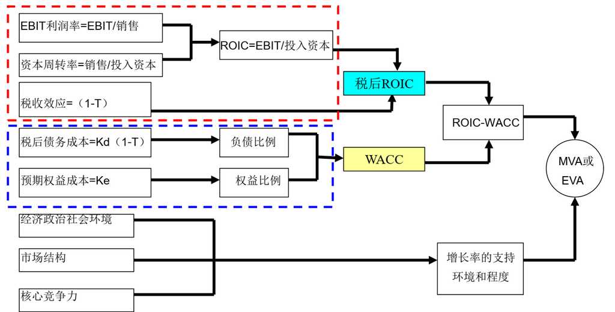

- 提高EVA的五大手段
  1. 提高经营利润率：
     - 降低销售成本、销售费用和管理费用；
  2. 加快投入资本周转速度：
     - 加强应收账款和存货管理，提高二者的周转速度；
     - 提高现有长期资产的使用效率；
     - 降低投入资本；
     - 使用无息负债；
  3. 减少实际税率：
     - 争取享受税惠政策、合理延迟纳税；
  4. 适度、平衡增长：
     - 确定合理、长期、可持续的、有效或高效的增长速度，有助于降低筹资成本；
  5. 降低WACC：
     - 尽量寻求低成本的资本，并合理利用负债，降低加权平均资本成本。

#### 成长模式：自我可持续成长能力的影响因素分解

- 实际增长率:$$ G = \frac{{销售收入}_t - {销售收入}_{t-1}}{{销售收入}_{t-1}} $$
- 可持续增长率：$$ g^* = \frac{期末股东权益－期初股东权益}{期初股东权益} $$
  - 推导： \begin{aligned} g^* &= \frac{期末股东权益－期初股东权益}{期初股东权益} \\ &= \frac{净利润\times 留存比率}{期初股东权益} \\ &= \frac{净利润}{期初股东权益}\times 留存比率 \\ &\approx ROE \times 留存比率 \end{aligned}
- 分解可持续增长率：
  - $$ g^*=\frac{净利润}{销售收入} ✕ \frac{销售收入}{总资产 }✕ \frac{总资产}{股东权益} ✕ 留存收益比例 $$
  - $$ g^* = 净 利 润 率\times 总 资 产 周 转 率\times 财 务 杠 杆\times 留存收益比例 $$
    - 其中$净 利 润 率\times 总 资 产 周 转 率$表示经营政策；$财 务 杠 杆\times 留存收益比例$表示财务政策
- 意义：
  1. 一个公司的增长既取决于当年所获得的股东权益回报率，更重要的是还取决于为股东留下多少增长的资金
1. 在给定公司的利润率和总资产周转率以及和留存收益比率和财务杠杆的条件下，一个公司所能实现的最大可能的增长率
1. 任何一个公司如果要以超过它的自我可持续增长率增长时，它就必须改变其中的一个或多个财务指标
- 过度增长 & 增长不足
  - 过度增长：现金短缺
    - 应对策略：
      1. 改进经营政策(提高净利润率与资产周转率)
      2. 提高财务杠杆
      3. 削减股利支付比率
      4. 增发新股
  - 增长不足：现金积压
    - 应对策略：
      1. 忽略问题
      2. 把钱还给股东：发放股利
      3. 买增长：扩大投资
- 案例：春秋航空
  - 著名廉价航空
  - 特点：
    - 低票价
    - 高客座率
    - 高飞机利用率
    - 无多余服务
    - 单一机型，取消商务舱
- 财务战略矩阵

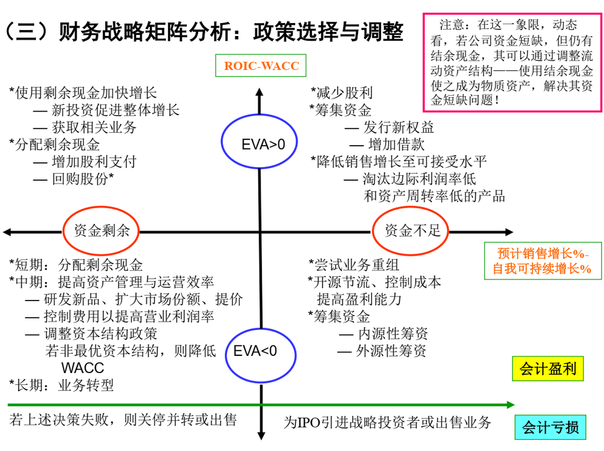